Data analysis for:

Padilla Perez, D.J. & Angilletta Jr., M.J. (2022). Macroclimatic and maternal effects on the evolution of reproductive traits in lizards. *Ecology and Evolution*.

[Dylan J. Padilla Perez](https://dylanpadilla.netlify.app/), School of Life Sciences, Arizona State University, Tempe, AZ 85287, USA.

**Library**

```r
require(geiger)
require(caper)
require(phylopath)
require(ggplot2)
require(ggtree)
require(ggtreeExtra)
require(gridExtra)
require(grid)
require(ggraph)
require(kableExtra)
```

```r
R.version
```

```
                 _
  platform       x86_64-apple-darwin17.0
  arch           x86_64
  os             darwin17.0
  system         x86_64, darwin17.0
  status
  major          4
  minor          1.1
  year           2021
  month          08
  day            10
  svn rev        80725
  language       R
  version.string R version 4.1.1 (2021-08-10)
  nickname       Kick Things
```

```r
data <- read.csv("sites.csv", row.names = 1)
data_bt <- read.csv("sps_body_temp.csv", row.names = 1)
qgis_data <- read.csv("qgis_data.csv", row.names = 1)
tree <- read.tree("tree.nex")

colnames(qgis_data)[1] <- "Binomial"
mer_data <- merge(qgis_data, data, by = "Binomial")
mer_data <- na.omit(mer_data)
rownames(mer_data) <- mer_data$Binomial

mer2 <- merge(data_bt, qgis_data, by = "Binomial")
mer2 <- na.omit(mer2)
rownames(mer2) <- mer2$Binomial
head(mer2)
```

```
                                                     Binomial reproductive.mode
  Ablepharus_rueppellii                 Ablepharus_rueppellii         Oviparous
  Acanthocercus_atricollis           Acanthocercus_atricollis         Oviparous
  Acanthodactylus_beershebensis Acanthodactylus_beershebensis         Oviparous
  Acanthodactylus_boskianus         Acanthodactylus_boskianus         Oviparous
  Acanthodactylus_erythrurus       Acanthodactylus_erythrurus         Oviparous
  Acanthodactylus_longipes           Acanthodactylus_longipes         Oviparous
                                          Genus     Family female.SVL
  Ablepharus_rueppellii              Ablepharus  Scincidae       35.3
  Acanthocercus_atricollis        Acanthocercus   Agamidae      113.9
  Acanthodactylus_beershebensis Acanthodactylus Lacertidae       64.9
  Acanthodactylus_boskianus     Acanthodactylus Lacertidae       60.1
  Acanthodactylus_erythrurus    Acanthodactylus Lacertidae       68.6
  Acanthodactylus_longipes      Acanthodactylus Lacertidae       46.7
                                hatchling.neonate.SVL intercept slope female_mass
  Ablepharus_rueppellii                          18.5    -5.125 3.229     108.859
  Acanthocercus_atricollis                       34.0    -4.686 3.105     348.974
  Acanthodactylus_beershebensis                  25.0    -4.543 2.951     186.977
  Acanthodactylus_boskianus                      26.5    -4.543 2.951     172.812
  Acanthodactylus_erythrurus                     29.0    -4.543 2.951     197.896
  Acanthodactylus_longipes                       23.0    -4.543 2.951     133.269
                                hatchling_mass largest.clutch smallest.clutch
  Ablepharus_rueppellii                 54.612              6               1
  Acanthocercus_atricollis             100.884             17               1
  Acanthodactylus_beershebensis         69.232              8               3
  Acanthodactylus_boskianus             73.659              8               1
  Acanthodactylus_erythrurus            81.036              8               1
  Acanthodactylus_longipes              63.330              3               2
                                largest.mean.clutch.size
  Ablepharus_rueppellii                              2.1
  Acanthocercus_atricollis                          11.4
  Acanthodactylus_beershebensis                      5.0
  Acanthodactylus_boskianus                          6.0
  Acanthodactylus_erythrurus                         4.4
  Acanthodactylus_longipes                           2.7
                                smallest.mean.clutch.size
  Ablepharus_rueppellii                               1.5
  Acanthocercus_atricollis                           11.4
  Acanthodactylus_beershebensis                       4.8
  Acanthodactylus_boskianus                           2.6
```

[output cut: 29 more lines]

```
  Acanthodactylus_longipes       7872081.195    74 R05268 lizard     1 24.79255
                                tempstdev  precmean precstdev       nppmean
  Ablepharus_rueppellii          2.291782 331.94857 272.92336  1.117030e+11
  Acanthocercus_atricollis       2.625608 972.20640 353.10011 -3.090000e+36
  Acanthodactylus_beershebensis  1.000428 228.63529  52.64411  7.397952e+10
  Acanthodactylus_boskianus      3.621189 134.28716 192.42539 -6.070000e+34
  Acanthodactylus_erythrurus     2.640014 532.20965 291.77357  1.976960e+11
  Acanthodactylus_longipes       2.899974  40.91517  40.48316  2.278848e+10
                                    nppstdev
  Ablepharus_rueppellii         8.925095e+10
  Acanthocercus_atricollis      3.230000e+37
  Acanthodactylus_beershebensis 4.821400e+10
  Acanthodactylus_boskianus     4.550000e+36
  Acanthodactylus_erythrurus    1.139040e+11
  Acanthodactylus_longipes      7.978077e+09
```

```r
tapply(data$annual_temp, data$Family, length)
```

```
           Agamidae    Amphisbaenidae          Anguidae       Anniellidae
                 95                 2                18                 2
          Bipedidae    Chamaeleonidae        Cordylidae    Corytophanidae
                  1                10                 7                 5
      Crotaphytidae       Dactyloidae   Diplodactylidae        Gekkonidae
                  5                67                 3                33
     Gerrhosauridae  Gymnophthalmidae    Helodermatidae     Hoplocercidae
                  2                34                 2                 3
          Iguanidae        Lacertidae    Leiocephalidae      Leiosauridae
                 15                83                 5                 3
        Liolaemidae         Opluridae   Phrynosomatidae  Phyllodactylidae
                 29                 2                70                 8
      Polychrotidae       Pygopodidae         Scincidae     Shinisauridae
                  2                10               218                 1
  Sphaerodactylidae           Teiidae    Trogonophiidae      Tropiduridae
                 22                43                 1                20
          Varanidae       Xantusiidae      Xenosauridae
                 34                 3                 7
```

```r
tapply(mer_data$annual_temp, mer_data$Family, length)
```

```
           Agamidae    Amphisbaenidae          Anguidae       Anniellidae
                 84                 2                18                 2
          Bipedidae    Chamaeleonidae        Cordylidae    Corytophanidae
                  1                 9                 7                 5
      Crotaphytidae       Dactyloidae   Diplodactylidae        Gekkonidae
                  5                67                 3                31
     Gerrhosauridae  Gymnophthalmidae    Helodermatidae     Hoplocercidae
                  2                24                 2                 3
          Iguanidae        Lacertidae    Leiocephalidae      Leiosauridae
                 15                75                 5                 3
        Liolaemidae         Opluridae   Phrynosomatidae  Phyllodactylidae
                 29                 2                69                 6
      Polychrotidae       Pygopodidae         Scincidae     Shinisauridae
                  2                 9               190                 1
  Sphaerodactylidae           Teiidae    Trogonophiidae      Tropiduridae
                 22                27                 1                19
          Varanidae       Xantusiidae      Xenosauridae
                 29                 3                 7
```

```r
tapply(mer2$female.SVL, mer2$Family, length)
```

```
           Agamidae    Amphisbaenidae          Anguidae       Anniellidae
                 45                 2                10                 1
          Bipedidae  Carphodactylidae    Chamaeleonidae        Cordylidae
                  2                 4                 5                 3
     Corytophanidae     Crotaphytidae       Dactyloidae   Diplodactylidae
                  2                 3                55                19
      Eublepharidae        Gekkonidae    Gerrhosauridae  Gymnophthalmidae
                  5                24                 1                15
     Helodermatidae     Hoplocercidae         Iguanidae        Lacertidae
                  2                 1                12                61
     Leiocephalidae       Liolaemidae         Opluridae   Phrynosomatidae
                  4                24                 1                57
   Phyllodactylidae     Polychrotidae       Pygopodidae         Scincidae
                 15                 2                 4               103
  Sphaerodactylidae           Teiidae    Trogonophiidae      Tropiduridae
                  9                25                 1                13
          Varanidae       Xantusiidae      Xenosauridae
                 17                 5                 6
```

```r
## Environmental temperature dataset

n1 <- mer_data[mer_data$Family != "Amphisbaenidae", ]


## Body temperature data

b1 <- mer2[mer2$Family != "Amphisbaenidae", ]
dat <- (n1)


dat$mclutch <- (dat$smallest.mean.clutch.size + dat$largest.mean.clutch.size) / 2


## Data for the Phylogeny

n2 <- data[data$Family != "Amphisbaenidae", ]
dtree <- n2
names(dtree)
```

```
   [1] "annual_temp"
   [2] "reproductive.mode"
   [3] "Binomial"
   [4] "Genus"
   [5] "Family"
   [6] "female.SVL"
   [7] "hatchling.neonate.SVL"
   [8] "intercept"
   [9] "slope"
  [10] "female_mass"
  [11] "hatchling_mass"
  [12] "largest.clutch"
  [13] "smallest.clutch"
  [14] "largest.mean.clutch.size"
  [15] "smallest.mean.clutch.size"
  [16] "Longitude.centroid..from.Roll.et.al..2017."
  [17] "Latitude.centroid..from.Roll.et.al..2017."
  [18] "Activity.time"
```

```r
dtree$mclutch <- (dtree$smallest.mean.clutch.size + dtree$largest.mean.clutch.size) / 2


check_t <- name.check(tree, dtree)
rm_phy_t <- check_t$tree_not_data
rm_dat_t <- check_t$data_not_tree
ctree_t <- drop.tip(tree, rm_phy_t)
dtree <- subset(dtree, subset = dtree$Binomial %in% ctree_t$tip, select = names(dtree)[1:19])
name.check(ctree_t, dtree)
```

```
  [1] "OK"
```

```r
ctree_t
```

```
  Phylogenetic tree with 669 tips and 668 internal nodes.

  Tip labels:
    Delma_australis, Delma_tincta, Delma_butleri, Delma_fraseri, Delma_grayii, Lialis_burtonis, ...

  Rooted; includes branch lengths.
```

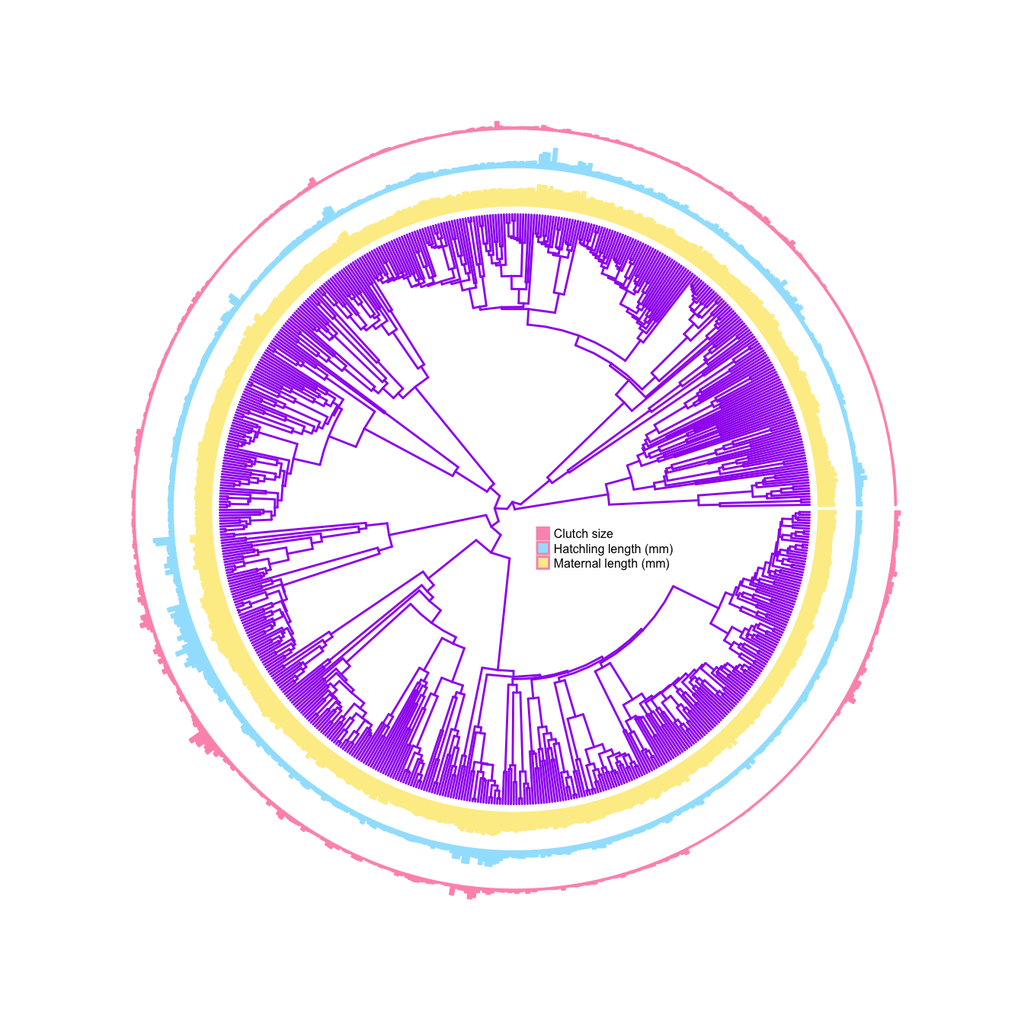

```r
p <- ggtree(ctree_t, layout='circular', colour = "purple")


p + geom_fruit(data=dtree, geom=geom_bar, mapping=aes(x=log(female.SVL), y = Binomial, fill = "Maternal length (mm)"), pwidth = 0.1, stat="identity", orientation="y", colour = "#FDED95") + geom_fruit(data=dtree, geom=geom_bar, mapping=aes(x=hatchling.neonate.SVL, y = Binomial, fill = "Hatchling length (mm)"), pwidth = 0.1, stat="identity", orientation="y", colour = "#A0E3FE") + geom_fruit(data=dtree, geom=geom_bar, mapping=aes(x=mclutch, y = Binomial, fill = "Clutch size"), pwidth = 0.07, stat="identity", orientation="y", colour = "#FE97BA") + scale_fill_manual(values=c("#FE97BA", "#A0E3FE", "#FDED95"), guide=guide_legend(keywidth=0.5, keyheight=0.5, order=6, title = "")) + theme(legend.position=c(0.59, 0.461), legend.title=element_text(size=0), legend.text=element_text(size=6), legend.spacing.x = unit(0.06, "cm"))
```

```r
dat_bt_diurnal <- (b1)


dat_bt_diurnal$mclutch <- (dat_bt_diurnal$smallest.mean.clutch.size + dat_bt_diurnal$largest.mean.clutch.size) / 2

dat_bt_diurnal$mean_bt <- (dat_bt_diurnal$minimum.mean.Tb + dat_bt_diurnal$maximum.mean.Tb) / 2

dat_bt_diurnal <- na.omit(dat_bt_diurnal)

tapply(dat_bt_diurnal$female.SVL, dat_bt_diurnal$Family, length)
```

```
           Agamidae          Anguidae       Anniellidae         Bipedidae
                 45                10                 1                 2
   Carphodactylidae    Chamaeleonidae        Cordylidae    Corytophanidae
                  4                 5                 3                 2
      Crotaphytidae       Dactyloidae   Diplodactylidae     Eublepharidae
                  3                55                19                 5
         Gekkonidae    Gerrhosauridae  Gymnophthalmidae    Helodermatidae
                 24                 1                15                 2
      Hoplocercidae         Iguanidae        Lacertidae    Leiocephalidae
                  1                12                61                 4
        Liolaemidae         Opluridae   Phrynosomatidae  Phyllodactylidae
                 24                 1                57                15
      Polychrotidae       Pygopodidae         Scincidae Sphaerodactylidae
                  2                 4               103                 9
            Teiidae    Trogonophiidae      Tropiduridae         Varanidae
                 25                 1                13                17
        Xantusiidae      Xenosauridae
                  5                 6
```

```r
names(dat_bt_diurnal)
```

```
   [1] "Binomial"
   [2] "reproductive.mode"
   [3] "Genus"
   [4] "Family"
   [5] "female.SVL"
   [6] "hatchling.neonate.SVL"
   [7] "intercept"
   [8] "slope"
   [9] "female_mass"
  [10] "hatchling_mass"
  [11] "largest.clutch"
  [12] "smallest.clutch"
  [13] "largest.mean.clutch.size"
  [14] "smallest.mean.clutch.size"
  [15] "Longitude.centroid..from.Roll.et.al..2017."
```

[output cut: 17 more lines]

```r
## Cheking whether the species names macth the tips of the tree

check <- name.check(tree, dat)
rm_phy <- check$tree_not_data
rm_dat <- check$data_not_tree

check_bt_diurnal <- name.check(tree, dat_bt_diurnal)
rm_phy_bt_diurnal <- check_bt_diurnal$tree_not_data
rm_dat_bt_diurnal <- check_bt_diurnal$data_not_tree


## Droping species names from the phylogeny

ctree <- drop.tip(tree, rm_phy)
ctree_bt_diurnal <- drop.tip(tree, rm_phy_bt_diurnal)

cdat <- subset(dat, subset = dat$Binomial %in% ctree$tip, select = names(dat)[1:30])
name.check(ctree, cdat)
```

```
  [1] "OK"
```

```r
names(cdat)
```

```
   [1] "Binomial"
   [2] "Area"
   [3] "FID_2"
   [4] "TID"
   [5] "Group"
   [6] "Value"
   [7] "tempmean"
   [8] "tempstdev"
   [9] "precmean"
  [10] "precstdev"
  [11] "nppmean"
  [12] "nppstdev"
  [13] "annual_temp"
  [14] "reproductive.mode"
  [15] "Genus"
  [16] "Family"
  [17] "female.SVL"
  [18] "hatchling.neonate.SVL"
  [19] "intercept"
  [20] "slope"
  [21] "female_mass"
  [22] "hatchling_mass"
  [23] "largest.clutch"
  [24] "smallest.clutch"
  [25] "largest.mean.clutch.size"
  [26] "smallest.mean.clutch.size"
  [27] "Longitude.centroid..from.Roll.et.al..2017."
  [28] "Latitude.centroid..from.Roll.et.al..2017."
  [29] "Activity.time"
  [30] "mclutch"
```

```r
names(cdat)[c(17, 18, 30, 7, 11, 9)] <- c("FS", "HS", "CS", "ET", "PP", "PR")


cdat$PR <- log1p(cdat$PR)
cdat$PP <- log1p(cdat$PP)
cdat <- na.omit(cdat)

check <- name.check(tree, cdat)
rm_phy <- check$tree_not_data
rm_dat <- check$data_not_tree
ctree <- drop.tip(tree, rm_phy)
name.check(ctree, cdat)
```

```
  [1] "OK"
```

```r
str(cdat)
```

```
  'data.frame': 439 obs. of  30 variables:
   $ Binomial                                  : chr  "Abronia_graminea" "Acanthodactylus_beershebensis" "Acanthodactylus_erythrurus" "Acanthodactylus_longipes" ...
   $ Area                                      : num  2037 5380 1030082 7872081 179337 ...
   $ FID_2                                     : int  21 56 64 74 81 85 86 107 129 241 ...
   $ TID                                       : chr  "R00677" "R05250" "R05258" "R05268" ...
   $ Group                                     : chr  "lizard" "lizard" "lizard" "lizard" ...
   $ Value                                     : int  1 1 1 1 1 1 1 1 1 1 ...
   $ ET                                        : num  11.8 19.1 14.7 24.8 19.5 ...
   $ tempstdev                                 : num  3.19 1 2.64 2.9 1.14 ...
   $ PR                                        : num  7.03 5.44 6.28 3.74 4.69 ...
   $ precstdev                                 : num  289.1 52.6 291.8 40.5 81.6 ...
   $ PP                                        : num  27.2 25 26 23.8 24.4 ...
   $ nppstdev                                  : num  1.13e+11 4.82e+10 1.14e+11 7.98e+09 5.03e+10 ...
   $ annual_temp                               : num  19 19.1 12.9 24.7 18.5 ...
   $ reproductive.mode                         : chr  "Viviparous" "Oviparous" "Oviparous" "Oviparous" ...
```

[output cut: 18 more lines]

```r
cdat_bt_diurnal <- subset(dat_bt_diurnal, subset = dat_bt_diurnal$Binomial %in% ctree_bt_diurnal$tip, select = names(dat_bt_diurnal)[1:32])
name.check(ctree_bt_diurnal, cdat_bt_diurnal)
```

```
  [1] "OK"
```

```r
names(cdat_bt_diurnal)
```

```
   [1] "Binomial"
   [2] "reproductive.mode"
   [3] "Genus"
   [4] "Family"
   [5] "female.SVL"
   [6] "hatchling.neonate.SVL"
   [7] "intercept"
   [8] "slope"
   [9] "female_mass"
  [10] "hatchling_mass"
  [11] "largest.clutch"
  [12] "smallest.clutch"
  [13] "largest.mean.clutch.size"
  [14] "smallest.mean.clutch.size"
  [15] "Longitude.centroid..from.Roll.et.al..2017."
```

[output cut: 17 more lines]

```r
names(cdat_bt_diurnal)[c(5, 6, 31, 32, 29, 27)] <- c("FS", "HS", "CS", "BT", "PP", "PR")

cdat_bt_diurnal$PR <- log1p(cdat_bt_diurnal$PR)
cdat_bt_diurnal$PP <- log(cdat_bt_diurnal$PP)

cdat_bt_diurnal <- na.omit(cdat_bt_diurnal)

check_bt_diurnal <- name.check(tree, cdat_bt_diurnal)
rm_phy_bt_diurnal <- check_bt_diurnal$tree_not_data
rm_dat_bt_diurnal <- check_bt_diurnal$data_not_tree
ctree_bt_diurnal <- drop.tip(tree, rm_phy_bt_diurnal)
name.check(ctree_bt_diurnal, cdat_bt_diurnal)
```

```
  [1] "OK"
```

```r
str(cdat_bt_diurnal)
```

```
  'data.frame': 320 obs. of  32 variables:
   $ Binomial                                  : chr  "Acanthodactylus_beershebensis" "Acanthodactylus_erythrurus" "Acanthodactylus_longipes" "Acanthodactylus_pardalis" ...
   $ reproductive.mode                         : chr  "Oviparous" "Oviparous" "Oviparous" "Oviparous" ...
   $ Genus                                     : chr  "Acanthodactylus" "Acanthodactylus" "Acanthodactylus" "Acanthodactylus" ...
   $ Family                                    : chr  "Lacertidae" "Lacertidae" "Lacertidae" "Lacertidae" ...
   $ FS                                        : num  64.9 68.6 46.7 61 69.4 ...
   $ HS                                        : num  25 29 23 30 35.8 24.3 79 29 20.4 22 ...
   $ intercept                                 : num  -4.54 -4.54 -4.54 -4.54 -4.54 ...
   $ slope                                     : num  2.95 2.95 2.95 2.95 2.95 ...
   $ female_mass                               : num  187 198 133 175 200 ...
   $ hatchling_mass                            : num  69.2 81 63.3 84 101.1 ...
   $ largest.clutch                            : int  8 8 3 7 8 6 4 20 8 8 ...
   $ smallest.clutch                           : int  3 1 2 2 1 1 2 4 1 2 ...
   $ largest.mean.clutch.size                  : num  5 4.4 2.7 4.8 3 3.3 3 14 3.3 4 ...
   $ smallest.mean.clutch.size                 : num  4.8 3 2.7 2.5 2.6 2.5 3 13.4 3.3 3 ...
```

[output cut: 20 more lines]

```r
ml3 <- define_model_set(
    null = c(),
    "(a)" = c(HS ~ ET),
    "(b)" = c(FS ~ ET),
    "(c)" = c(FS ~ ET, HS ~ ET),
    "(d)" = c(FS ~ PP),
    "(e)" = c(FS ~ PR),
    "(f)" = c(HS ~ PR),
    "(g)" = c(FS ~ PR, HS ~ PR),
    "(h)" = c(FS ~ PP + PR + ET, HS ~ ET, HS ~ PR),
    .common = c(CS ~ FS + HS, HS ~ FS, ET ~ PR, PP ~ ET, PP ~ PR))



ml4 <- define_model_set(
    null = c(),
    "(a)" = c(HS ~ BT),
    "(b)" = c(FS ~ BT),
    "(c)" = c(FS ~ BT, HS ~ BT),
    "(d)" = c(FS ~ PP),
    "(e)" = c(FS ~ PR),
    "(f)" = c(HS ~ PR),
    "(g)" = c(FS ~ PR, HS ~ PR),
    "(h)" = c(FS ~ PP + PR + BT, HS ~ BT, HS ~ PR),
    .common = c(CS ~ FS + HS, HS ~ FS, BT ~ PR, BT ~ PP, PP ~ PR))
```

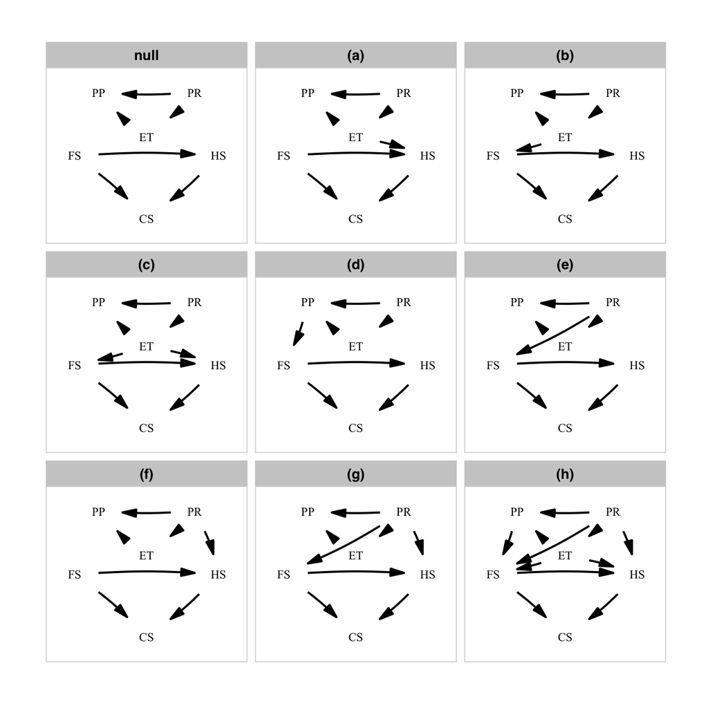

```r
set_graph_style(family = "Times New Roman")

positions <- data.frame(name = c('PP', 'PR', 'ET', 'FS', 'HS', '', 'CS'), x = c(2:3, c(2.5, 1.75, 3.25, 2), 2.5), y = c(3, 3, 2.3, 2, 2, 2, 1))

plot_model_set(ml3, manual_layout = positions, text_size = 3, edge_width = 0.7)
```

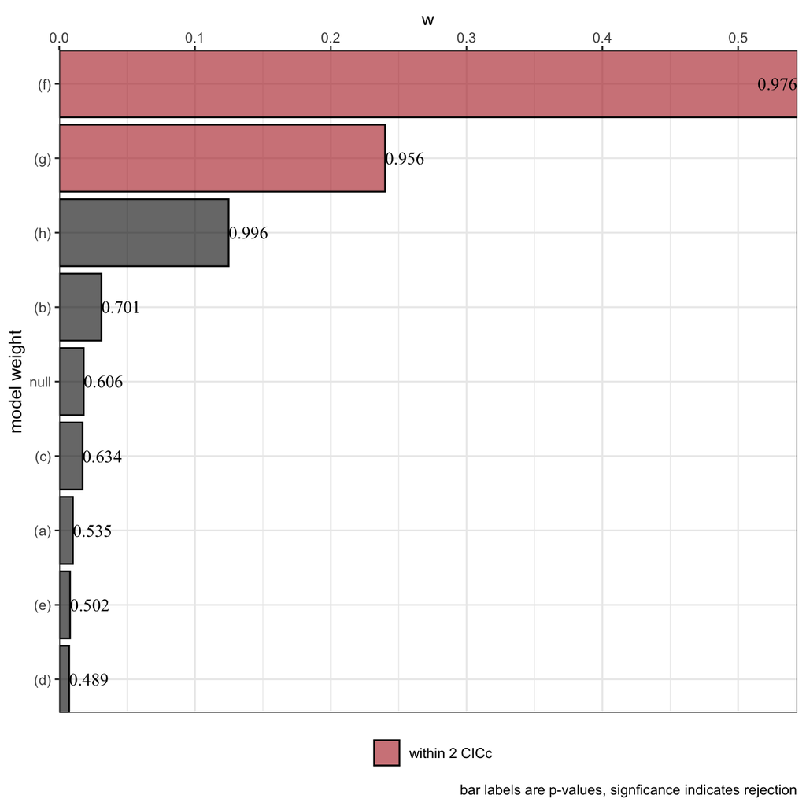

```r
mo <- phylo_path(ml3, cdat, ctree)
s <- summary(mo)
theme_set(theme_bw())
plot(s)
```

**Table S1.**

```r
kable(summary(mo)[ , 2:9], digits = 3) %>%
  kable_styling(bootstrap_options = "striped", full_width = FALSE, position = "center")
```

k

q

C

p

CICc

delta_CICc

l

w

8

13

6.880

0.976

33.736

0.000

1.000

0.544

7

14

6.381

0.956

35.371

1.635

0.441

0.240

4

17

1.226

0.996

36.679

2.943

0.230

0.125

8

13

12.605

0.701

39.461

5.725

0.057

0.031

null

9

12

15.812

0.606

40.545

6.809

0.033

0.018

7

14

11.649

0.634

40.639

6.903

0.032

0.017

8

13

14.856

0.535

41.713

7.977

0.019

0.010

8

13

15.313

0.502

42.170

8.434

0.015

0.008

8

13

15.492

0.489

42.348

8.612

0.013

0.007

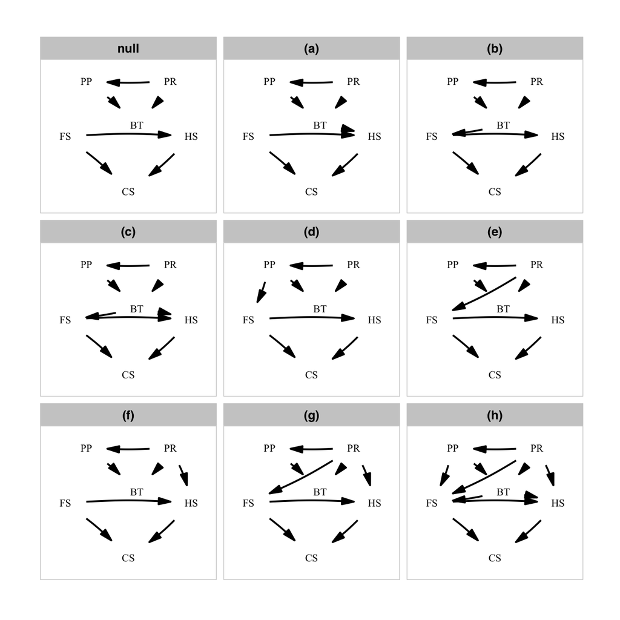

```r
positions.bt <- data.frame(name = c('PP', 'PR', 'BT', 'FS', 'HS', '', 'CS'), x = c(2:3, c(2.6, 1.75, 3.25, 2), 2.5), y = c(3, 3, 2.2, 2, 2, 2, 1))

set_graph_style(family = "Times New Roman")


plot_model_set(ml4, manual_layout = positions.bt, text_size = 3, edge_width = 0.7)
```

**Figure 1.** Path models depicting relationships among body temperature and life-history traits derived from optimality models (see text for details). Abbreviation in the path diagrams are as follows: BT = body temperature; CS = clutch size; FS = maternal length; HS = hatchling/neonate length; PP = primary production; PR = annual precipitation.

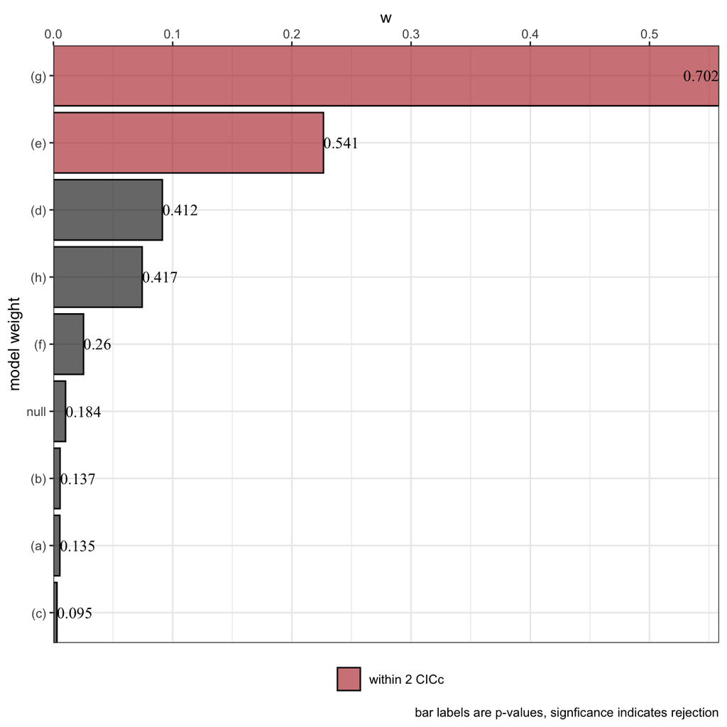

```r
mo_bt_diurnal <- phylo_path(ml4, cdat_bt_diurnal, ctree_bt_diurnal)
s.bt <- summary(mo_bt_diurnal)
theme_set(theme_bw())
plot(s.bt)
```

**Figure 4.** Relative importance of the causal models describing the evolution of reproductive traits in lizards.

**Table S2.**

```r
kable(summary(mo_bt_diurnal)[ , 2:9], digits = 3) %>%
  kable_styling(bootstrap_options = "striped", full_width = FALSE, position = "center")
```

k

q

C

p

CICc

delta_CICc

l

w

7

14

10.791

0.702

40.168

0.000

1.000

0.558

8

13

14.783

0.541

41.972

1.804

0.406

0.227

8

13

16.598

0.412

43.788

3.620

0.164

0.091

4

17

8.171

0.417

44.198

4.030

0.133

0.074

8

13

19.172

0.260

46.362

6.194

0.045

0.025

null

9

12

23.164

0.184

48.180

8.012

0.018

0.010

8

13

22.191

0.137

49.381

9.213

0.010

0.006

8

13

22.253

0.135

49.443

9.275

0.010

0.005

7

14

21.280

0.095

50.657

10.489

0.005

0.003

```r
mo$d_sep
```

```
  $null
  # A tibble: 9 × 4
    d_sep                            p phylo_par model
    <chr>                        <dbl>     <dbl> <list>
  1 FS ~ PR                     0.779      0.985 <phylolm>
  2 HS ~ FS + PR                0.0115     0.853 <phylolm>
  3 CS ~ FS + HS + PR           0.940      0.956 <phylolm>
  4 FS ~ PR + ET                0.158      0.985 <phylolm>
  5 HS ~ PR + FS + ET           0.484      0.853 <phylolm>
  6 CS ~ PR + FS + HS + ET      0.629      0.954 <phylolm>
  7 FS ~ PR + ET + PP           0.992      0.985 <phylolm>
  8 HS ~ PR + ET + FS + PP      0.944      0.853 <phylolm>
  9 CS ~ PR + ET + FS + HS + PP 0.972      0.954 <phylolm>

  $`(a)`
  # A tibble: 8 × 4
    d_sep                             p phylo_par model
    <chr>                         <dbl>     <dbl> <list>
  1 FS ~ PR                     0.779       0.985 <phylolm>
  2 HS ~ ET + FS + PR           0.00898     0.853 <phylolm>
  3 CS ~ FS + HS + PR           0.940       0.956 <phylolm>
  4 FS ~ PR + ET                0.158       0.985 <phylolm>
  5 CS ~ PR + FS + HS + ET      0.629       0.954 <phylolm>
  6 FS ~ PR + ET + PP           0.992       0.985 <phylolm>
  7 HS ~ PR + ET + FS + PP      0.944       0.853 <phylolm>
  8 CS ~ PR + ET + FS + HS + PP 0.972       0.954 <phylolm>

  $`(b)`
  # A tibble: 8 × 4
    d_sep                            p phylo_par model
    <chr>                        <dbl>     <dbl> <list>
  1 FS ~ ET + PR                0.613      0.985 <phylolm>
  2 HS ~ FS + PR                0.0115     0.853 <phylolm>
  3 CS ~ FS + HS + PR           0.940      0.956 <phylolm>
  4 HS ~ PR + FS + ET           0.484      0.853 <phylolm>
  5 CS ~ PR + FS + HS + ET      0.629      0.954 <phylolm>
  6 FS ~ PR + ET + PP           0.992      0.985 <phylolm>
  7 HS ~ PR + ET + FS + PP      0.944      0.853 <phylolm>
  8 CS ~ PR + ET + FS + HS + PP 0.972      0.954 <phylolm>

```

[output cut: 56 more lines]

```
  2 FS ~ PR + ET                0.158     0.985 <phylolm>
  3 HS ~ PR + FS + ET           0.484     0.853 <phylolm>
  4 CS ~ PR + FS + HS + ET      0.629     0.954 <phylolm>
  5 FS ~ PR + ET + PP           0.992     0.985 <phylolm>
  6 HS ~ PR + ET + FS + PP      0.944     0.853 <phylolm>
  7 CS ~ PR + ET + FS + HS + PP 0.972     0.954 <phylolm>

  $`(h)`
  # A tibble: 4 × 4
    d_sep                           p phylo_par model
    <chr>                       <dbl>     <dbl> <list>
  1 CS ~ FS + HS + PR           0.940     0.956 <phylolm>
  2 CS ~ PR + FS + HS + ET      0.629     0.954 <phylolm>
  3 HS ~ PR + ET + FS + PP      0.944     0.853 <phylolm>
  4 CS ~ PR + ET + FS + HS + PP 0.972     0.954 <phylolm>
```

```r
mo_bt_diurnal$d_sep
```

```
  $null
  # A tibble: 9 × 4
    d_sep                            p phylo_par model
    <chr>                        <dbl>     <dbl> <list>
  1 FS ~ PR                     0.0151     0.994 <phylolm>
  2 HS ~ FS + PR                0.136      0.868 <phylolm>
  3 CS ~ FS + HS + PR           0.448      0.811 <phylolm>
  4 FS ~ PR + PP                0.718      0.994 <phylolm>
  5 HS ~ PR + FS + PP           0.652      0.867 <phylolm>
  6 CS ~ PR + FS + HS + PP      0.796      0.813 <phylolm>
  7 FS ~ PR + PP + BT           0.669      0.994 <phylolm>
  8 HS ~ PR + PP + FS + BT      0.547      0.867 <phylolm>
  9 CS ~ PR + PP + FS + HS + BT 0.0743     0.827 <phylolm>

  $`(a)`
  # A tibble: 8 × 4
    d_sep                            p phylo_par model
    <chr>                        <dbl>     <dbl> <list>
  1 FS ~ PR                     0.0151     0.994 <phylolm>
  2 HS ~ BT + FS + PR           0.120      0.868 <phylolm>
  3 CS ~ FS + HS + PR           0.448      0.811 <phylolm>
  4 FS ~ PR + PP                0.718      0.994 <phylolm>
  5 HS ~ PR + BT + FS + PP      0.635      0.867 <phylolm>
  6 CS ~ PR + FS + HS + PP      0.796      0.813 <phylolm>
  7 FS ~ PR + PP + BT           0.669      0.994 <phylolm>
  8 CS ~ PR + PP + FS + HS + BT 0.0743     0.827 <phylolm>

  $`(b)`
  # A tibble: 8 × 4
    d_sep                            p phylo_par model
    <chr>                        <dbl>     <dbl> <list>
  1 FS ~ BT + PR                0.0161     0.994 <phylolm>
  2 HS ~ FS + PR                0.136      0.868 <phylolm>
  3 CS ~ FS + HS + PR           0.448      0.811 <phylolm>
  4 FS ~ PR + BT + PP           0.734      0.994 <phylolm>
  5 HS ~ PR + FS + PP           0.652      0.867 <phylolm>
  6 CS ~ PR + FS + HS + PP      0.796      0.813 <phylolm>
  7 HS ~ PR + PP + FS + BT      0.547      0.867 <phylolm>
  8 CS ~ PR + PP + FS + HS + BT 0.0743     0.827 <phylolm>

```

[output cut: 56 more lines]

```
  2 FS ~ PR + PP                0.718      0.994 <phylolm>
  3 HS ~ PR + FS + PP           0.652      0.867 <phylolm>
  4 CS ~ PR + FS + HS + PP      0.796      0.813 <phylolm>
  5 FS ~ PR + PP + BT           0.669      0.994 <phylolm>
  6 HS ~ PR + PP + FS + BT      0.547      0.867 <phylolm>
  7 CS ~ PR + PP + FS + HS + BT 0.0743     0.827 <phylolm>

  $`(h)`
  # A tibble: 4 × 4
    d_sep                            p phylo_par model
    <chr>                        <dbl>     <dbl> <list>
  1 CS ~ FS + HS + PR           0.448      0.811 <phylolm>
  2 HS ~ PR + BT + FS + PP      0.635      0.867 <phylolm>
  3 CS ~ PR + FS + HS + PP      0.796      0.813 <phylolm>
  4 CS ~ PR + PP + FS + HS + BT 0.0743     0.827 <phylolm>
```

**Model averaging**

```r
avg <- average(mo, avg_method = "full", cut_off = 2)
avg
```

```
  $coef
              FS PR        ET           PP          HS         CS
  FS 0.000000000  0 0.0000000  0.000000000  0.76738439  0.7262246
  PR 0.003628185  0 0.1801509  0.863724467 -0.05306196  0.0000000
  ET 0.000000000  0 0.0000000 -0.001114894  0.00000000  0.0000000
  PP 0.000000000  0 0.0000000  0.000000000  0.00000000  0.0000000
  HS 0.000000000  0 0.0000000  0.000000000  0.00000000 -0.5334417
  CS 0.000000000  0 0.0000000  0.000000000  0.00000000  0.0000000
  attr(,"class")
  [1] "matrix" "DAG"

  $se
             FS PR         ET         PP         HS         CS
  FS 0.00000000  0 0.00000000 0.00000000 0.02320332 0.08070812
  PR 0.02400088  0 0.04688044 0.02648326 0.02090524 0.00000000
  ET 0.00000000  0 0.00000000 0.02700766 0.00000000 0.00000000
  PP 0.00000000  0 0.00000000 0.00000000 0.00000000 0.00000000
  HS 0.00000000  0 0.00000000 0.00000000 0.00000000 0.09043611
  CS 0.00000000  0 0.00000000 0.00000000 0.00000000 0.00000000

  $lower
              FS PR         ET          PP          HS         CS
  FS  0.00000000  0 0.00000000  0.00000000  0.72190673  0.5680396
  PR -0.04341267  0 0.08826695  0.81181822 -0.09403547  0.0000000
  ET  0.00000000  0 0.00000000 -0.05404894  0.00000000  0.0000000
  PP  0.00000000  0 0.00000000  0.00000000  0.00000000  0.0000000
  HS  0.00000000  0 0.00000000  0.00000000  0.00000000 -0.7106932
  CS  0.00000000  0 0.00000000  0.00000000  0.00000000  0.0000000

  $upper
             FS PR        ET         PP          HS         CS
  FS 0.00000000  0 0.0000000 0.00000000  0.81286206  0.8844096
  PR 0.05066904  0 0.2720349 0.91563071 -0.01208844  0.0000000
  ET 0.00000000  0 0.0000000 0.05181915  0.00000000  0.0000000
  PP 0.00000000  0 0.0000000 0.00000000  0.00000000  0.0000000
  HS 0.00000000  0 0.0000000 0.00000000  0.00000000 -0.3561902
  CS 0.00000000  0 0.0000000 0.00000000  0.00000000  0.0000000

  attr(,"class")
  [1] "fitted_DAG"
```

```r
avg_bt_diurnal <- average(mo_bt_diurnal, avg_method = "full", cut_off = 2)
avg_bt_diurnal
```

```
  $coef
     PR        PP          BT        FS          HS         CS
  PR  0 0.8435276 -0.02689343 0.1177388 -0.02720096  0.0000000
  PP  0 0.0000000 -0.07015859 0.0000000  0.00000000  0.0000000
  BT  0 0.0000000  0.00000000 0.0000000  0.00000000  0.0000000
  FS  0 0.0000000  0.00000000 0.0000000  0.78788686  0.9299939
  HS  0 0.0000000  0.00000000 0.0000000  0.00000000 -0.7289029
  CS  0 0.0000000  0.00000000 0.0000000  0.00000000  0.0000000
  attr(,"class")
  [1] "matrix" "DAG"

  $se
     PR         PP         BT        FS         HS         CS
  PR  0 0.02900682 0.08927395 0.0482073 0.02766628 0.00000000
  PP  0 0.00000000 0.08849381 0.0000000 0.00000000 0.00000000
  BT  0 0.00000000 0.00000000 0.0000000 0.00000000 0.00000000
  FS  0 0.00000000 0.00000000 0.0000000 0.02862378 0.09956889
  HS  0 0.00000000 0.00000000 0.0000000 0.00000000 0.10600762
  CS  0 0.00000000 0.00000000 0.0000000 0.00000000 0.00000000

  $lower
     PR        PP         BT         FS          HS         CS
  PR  0 0.7866753 -0.2018672 0.02325428 -0.08142587  0.0000000
  PP  0 0.0000000 -0.2436033 0.00000000  0.00000000  0.0000000
  BT  0 0.0000000  0.0000000 0.00000000  0.00000000  0.0000000
  FS  0 0.0000000  0.0000000 0.00000000  0.73178528  0.7348424
  HS  0 0.0000000  0.0000000 0.00000000  0.00000000 -0.9366740
  CS  0 0.0000000  0.0000000 0.00000000  0.00000000  0.0000000

  $upper
     PR        PP        BT        FS         HS         CS
  PR  0 0.9003799 0.1480803 0.2122234 0.02702394  0.0000000
  PP  0 0.0000000 0.1032861 0.0000000 0.00000000  0.0000000
  BT  0 0.0000000 0.0000000 0.0000000 0.00000000  0.0000000
  FS  0 0.0000000 0.0000000 0.0000000 0.84398843  1.1251453
  HS  0 0.0000000 0.0000000 0.0000000 0.00000000 -0.5211317
  CS  0 0.0000000 0.0000000 0.0000000 0.00000000  0.0000000

  attr(,"class")
  [1] "fitted_DAG"
```

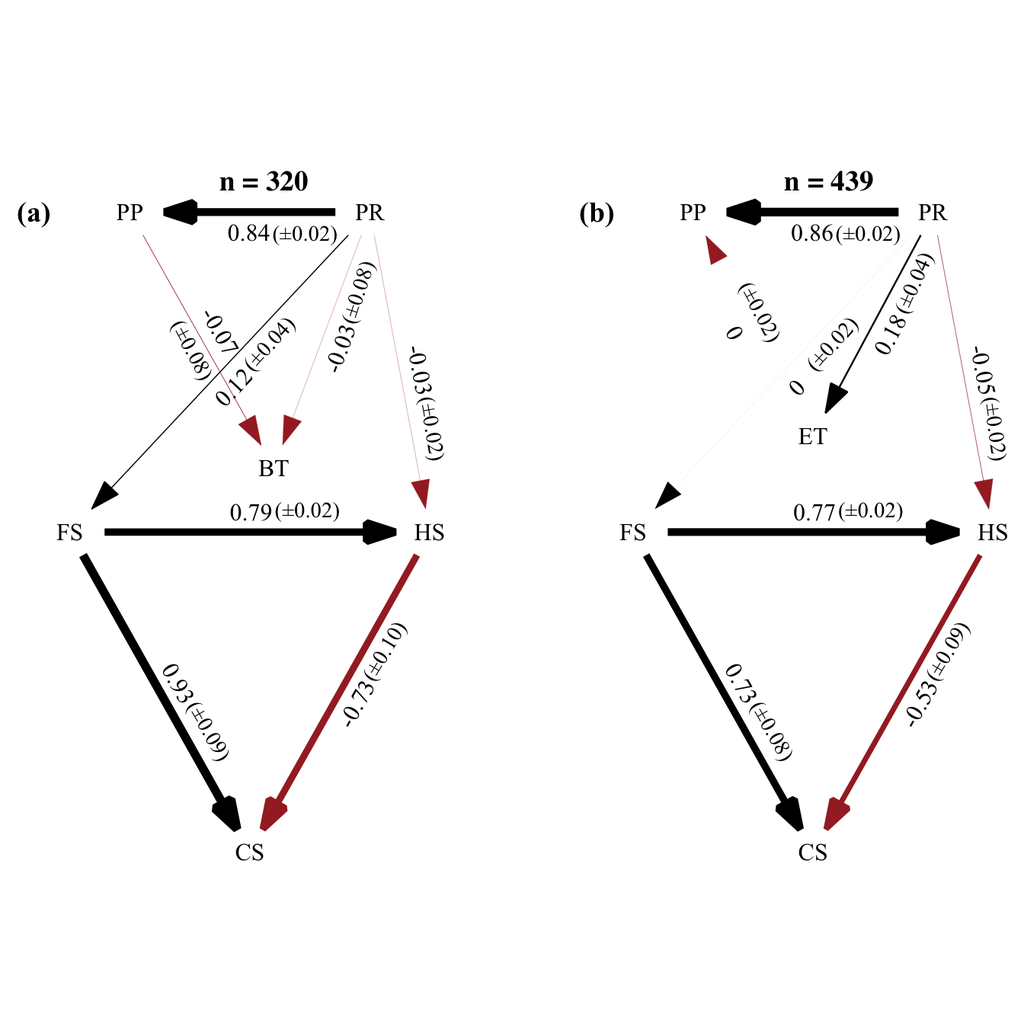

```r
set_graph_style(family = "Times New Roman", text_size = 12)

d2 <- plot(avg_bt_diurnal, manual_layout = positions.bt, text_size = 4.2, edge_width = 0.05, curvature = -0, colors = c("brown", "black")) + ggplot2::scale_x_continuous(expand = c(0.2, 0)) + ggplot2::scale_y_continuous(expand = c(0.1, 0)) + theme(plot.margin=unit(c(0, 0, 0, 0), "cm")) + theme(legend.text = element_text(size = 13, family = "serif")) + theme(plot.title = element_text(size = 14, family = "serif", face = "bold")) + annotate(geom = "text", x = 2.74, y = 2.07, angle = 0, label = "(±0.02)", size = 3.8) + annotate(geom = "text", angle = 300, x = 2.33, y = 1.38, label = "(±0.09)", size = 3.8) + annotate(geom = "text", x = 3.06, y = 1.63, angle = 59, label = "(±0.10)", size = 3.8) + ggtitle("n = 320") + theme(plot.title = element_text(hjust = 0.566, vjust = -10), legend.position = "none")

d3 <- plot(avg, manual_layout = positions, text_size = 4.2, edge_width = 0.05, curvature = -0, colors = c("brown", "black")) + ggplot2::scale_x_continuous(expand = c(0.2, 0)) + ggplot2::scale_y_continuous(expand = c(0.1, 0)) + theme(plot.margin=unit(c(0, 0, 0, 0), "cm")) + theme(legend.text = element_text(size = 13, family = "serif")) + theme(plot.title = element_text(size = 14, family = "serif", face = "bold")) + annotate(geom = "text", x = 2.74, y = 2.07, angle = 0, label = "(±0.02)", size = 3.8) + annotate(geom = "text", angle = 300, x = 2.33, y = 1.38, label = "(±0.08)", size = 3.8) + annotate(geom = "text", x = 3.06, y = 1.63, angle = 59, label = "(±0.09)", size = 3.8) + theme(plot.title = element_text(hjust = 0.57, vjust = -10), legend.position = "none") + ggtitle("n = 439")


grob <- grobTree(textGrob("(a)", x = 0.09,  y = 0.97, hjust = 0, gp = gpar(fontsize = 12, fontface = "bold", fontfamily = "Times New Roman")))

grob2 <- grobTree(textGrob("(b)", x = 0.09,  y = 0.97, hjust = 0, gp = gpar(fontsize = 12, fontface = "bold", fontfamily = "Times New Roman")))

c1 <- d2 + annotate(geom = "text", x = 2.73, y = 2.934, angle = 0, label = "(±0.02)", size = 3.8) + annotate(geom = "text", x = 3.26, y = 2.324, angle = 280, label = "(±0.02)", size = 3.8) + annotate(geom = "text", x = 2.26, y = 2.57, angle = 298, label = "(±0.08)", size = 3.8) + annotate(geom = "text", x = 2.95, y = 2.75, angle = 72, label = "(±0.08)", size = 3.8) + annotate(geom = "text", x = 2.58, y = 2.59, angle = 48, label = "(±0.04)", size = 3.8) + annotate(geom = "text", x = 1.6, y = 3, label = "(a)", size = 5, fontface = 2)

c2 <- d3 + annotate(geom = "text", x = 2.73, y = 2.934, angle = 0, label = "(±0.02)", size = 3.8) + annotate(geom = "text", x = 3.26, y = 2.324, angle = 278, label = "(±0.02)", size = 3.8) + annotate(geom = "text", x = 2.28, y = 2.69, angle = 298, label = "(±0.02)", size = 3.8) + annotate(geom = "text", x = 2.92, y = 2.78, angle = 66, label = "(±0.04)", size = 3.8) + annotate(geom = "text", x = 2.58, y = 2.59, angle = 48, label = "(±0.02)", size = 3.8) + annotate(geom = "text", x = 1.6, y = 3, label = "(b)", size = 5, fontface = 2)

quartz()
grid.arrange(grobs = list(c1, c2), ncol = 2, vp = viewport(width = 1.1, height = 0.8), layout_matrix = rbind(c(1, 2), c(1, 2)))
```

**Figure 2.** Best-fit models of the evolution of reproductive traits considering body temperature (a) and environmental temperature (b) as independent variable. Thicker arrows indicate stronger effects. Values in parentheses denote the standard errors of the path coefficients.

**The following section consists of the same analyses but, this time, we use female mass and hatchling mass as measures of maternal size and hatchling size.**

```r
rm(list = ls())



data <- read.csv("sites.csv", row.names = 1)
data_bt <- read.csv("sps_body_temp.csv", row.names = 1)
qgis_data <- read.csv("qgis_data.csv", row.names = 1)
tree <- read.tree("tree.nex")

colnames(qgis_data)[1] <- "Binomial"
mer_data <- merge(qgis_data, data, by = "Binomial")
mer_data <- na.omit(mer_data)
rownames(mer_data) <- mer_data$Binomial

mer2 <- merge(data_bt, qgis_data, by = "Binomial")
mer2 <- na.omit(mer2)
rownames(mer2) <- mer2$Binomial
head(mer2)
```

```
                                                     Binomial reproductive.mode
  Ablepharus_rueppellii                 Ablepharus_rueppellii         Oviparous
  Acanthocercus_atricollis           Acanthocercus_atricollis         Oviparous
  Acanthodactylus_beershebensis Acanthodactylus_beershebensis         Oviparous
  Acanthodactylus_boskianus         Acanthodactylus_boskianus         Oviparous
  Acanthodactylus_erythrurus       Acanthodactylus_erythrurus         Oviparous
  Acanthodactylus_longipes           Acanthodactylus_longipes         Oviparous
                                          Genus     Family female.SVL
  Ablepharus_rueppellii              Ablepharus  Scincidae       35.3
  Acanthocercus_atricollis        Acanthocercus   Agamidae      113.9
  Acanthodactylus_beershebensis Acanthodactylus Lacertidae       64.9
  Acanthodactylus_boskianus     Acanthodactylus Lacertidae       60.1
  Acanthodactylus_erythrurus    Acanthodactylus Lacertidae       68.6
  Acanthodactylus_longipes      Acanthodactylus Lacertidae       46.7
                                hatchling.neonate.SVL intercept slope female_mass
  Ablepharus_rueppellii                          18.5    -5.125 3.229     108.859
  Acanthocercus_atricollis                       34.0    -4.686 3.105     348.974
  Acanthodactylus_beershebensis                  25.0    -4.543 2.951     186.977
  Acanthodactylus_boskianus                      26.5    -4.543 2.951     172.812
  Acanthodactylus_erythrurus                     29.0    -4.543 2.951     197.896
  Acanthodactylus_longipes                       23.0    -4.543 2.951     133.269
                                hatchling_mass largest.clutch smallest.clutch
  Ablepharus_rueppellii                 54.612              6               1
  Acanthocercus_atricollis             100.884             17               1
  Acanthodactylus_beershebensis         69.232              8               3
  Acanthodactylus_boskianus             73.659              8               1
  Acanthodactylus_erythrurus            81.036              8               1
  Acanthodactylus_longipes              63.330              3               2
                                largest.mean.clutch.size
  Ablepharus_rueppellii                              2.1
  Acanthocercus_atricollis                          11.4
  Acanthodactylus_beershebensis                      5.0
  Acanthodactylus_boskianus                          6.0
  Acanthodactylus_erythrurus                         4.4
  Acanthodactylus_longipes                           2.7
                                smallest.mean.clutch.size
  Ablepharus_rueppellii                               1.5
  Acanthocercus_atricollis                           11.4
  Acanthodactylus_beershebensis                       4.8
  Acanthodactylus_boskianus                           2.6
```

[output cut: 29 more lines]

```
  Acanthodactylus_longipes       7872081.195    74 R05268 lizard     1 24.79255
                                tempstdev  precmean precstdev       nppmean
  Ablepharus_rueppellii          2.291782 331.94857 272.92336  1.117030e+11
  Acanthocercus_atricollis       2.625608 972.20640 353.10011 -3.090000e+36
  Acanthodactylus_beershebensis  1.000428 228.63529  52.64411  7.397952e+10
  Acanthodactylus_boskianus      3.621189 134.28716 192.42539 -6.070000e+34
  Acanthodactylus_erythrurus     2.640014 532.20965 291.77357  1.976960e+11
  Acanthodactylus_longipes       2.899974  40.91517  40.48316  2.278848e+10
                                    nppstdev
  Ablepharus_rueppellii         8.925095e+10
  Acanthocercus_atricollis      3.230000e+37
  Acanthodactylus_beershebensis 4.821400e+10
  Acanthodactylus_boskianus     4.550000e+36
  Acanthodactylus_erythrurus    1.139040e+11
  Acanthodactylus_longipes      7.978077e+09
```

```r
tapply(data$annual_temp, data$Family, length)
```

```
           Agamidae    Amphisbaenidae          Anguidae       Anniellidae
                 95                 2                18                 2
          Bipedidae    Chamaeleonidae        Cordylidae    Corytophanidae
                  1                10                 7                 5
      Crotaphytidae       Dactyloidae   Diplodactylidae        Gekkonidae
                  5                67                 3                33
     Gerrhosauridae  Gymnophthalmidae    Helodermatidae     Hoplocercidae
                  2                34                 2                 3
          Iguanidae        Lacertidae    Leiocephalidae      Leiosauridae
                 15                83                 5                 3
        Liolaemidae         Opluridae   Phrynosomatidae  Phyllodactylidae
                 29                 2                70                 8
      Polychrotidae       Pygopodidae         Scincidae     Shinisauridae
                  2                10               218                 1
  Sphaerodactylidae           Teiidae    Trogonophiidae      Tropiduridae
                 22                43                 1                20
          Varanidae       Xantusiidae      Xenosauridae
                 34                 3                 7
```

```r
tapply(mer_data$annual_temp, mer_data$Family, length)
```

```
           Agamidae    Amphisbaenidae          Anguidae       Anniellidae
                 84                 2                18                 2
          Bipedidae    Chamaeleonidae        Cordylidae    Corytophanidae
                  1                 9                 7                 5
      Crotaphytidae       Dactyloidae   Diplodactylidae        Gekkonidae
                  5                67                 3                31
     Gerrhosauridae  Gymnophthalmidae    Helodermatidae     Hoplocercidae
                  2                24                 2                 3
          Iguanidae        Lacertidae    Leiocephalidae      Leiosauridae
                 15                75                 5                 3
        Liolaemidae         Opluridae   Phrynosomatidae  Phyllodactylidae
                 29                 2                69                 6
      Polychrotidae       Pygopodidae         Scincidae     Shinisauridae
                  2                 9               190                 1
  Sphaerodactylidae           Teiidae    Trogonophiidae      Tropiduridae
                 22                27                 1                19
          Varanidae       Xantusiidae      Xenosauridae
                 29                 3                 7
```

```r
tapply(mer2$female.SVL, mer2$Family, length)
```

```
           Agamidae    Amphisbaenidae          Anguidae       Anniellidae
                 45                 2                10                 1
          Bipedidae  Carphodactylidae    Chamaeleonidae        Cordylidae
                  2                 4                 5                 3
     Corytophanidae     Crotaphytidae       Dactyloidae   Diplodactylidae
                  2                 3                55                19
      Eublepharidae        Gekkonidae    Gerrhosauridae  Gymnophthalmidae
                  5                24                 1                15
     Helodermatidae     Hoplocercidae         Iguanidae        Lacertidae
                  2                 1                12                61
     Leiocephalidae       Liolaemidae         Opluridae   Phrynosomatidae
                  4                24                 1                57
   Phyllodactylidae     Polychrotidae       Pygopodidae         Scincidae
                 15                 2                 4               103
  Sphaerodactylidae           Teiidae    Trogonophiidae      Tropiduridae
                  9                25                 1                13
          Varanidae       Xantusiidae      Xenosauridae
                 17                 5                 6
```

```r
## Environmental temperature dataset

n1 <- mer_data[mer_data$Family != "Amphisbaenidae", ]


## Body temperature data

b1 <- mer2[mer2$Family != "Amphisbaenidae", ]
dat <- (n1)


dat$mclutch <- (dat$smallest.mean.clutch.size + dat$largest.mean.clutch.size) / 2
tapply(dat$annual_temp, dat$Family, length)
```

```
           Agamidae          Anguidae       Anniellidae         Bipedidae
                 84                18                 2                 1
     Chamaeleonidae        Cordylidae    Corytophanidae     Crotaphytidae
                  9                 7                 5                 5
        Dactyloidae   Diplodactylidae        Gekkonidae    Gerrhosauridae
                 67                 3                31                 2
   Gymnophthalmidae    Helodermatidae     Hoplocercidae         Iguanidae
                 24                 2                 3                15
         Lacertidae    Leiocephalidae      Leiosauridae       Liolaemidae
                 75                 5                 3                29
          Opluridae   Phrynosomatidae  Phyllodactylidae     Polychrotidae
                  2                69                 6                 2
        Pygopodidae         Scincidae     Shinisauridae Sphaerodactylidae
                  9               190                 1                22
            Teiidae    Trogonophiidae      Tropiduridae         Varanidae
                 27                 1                19                29
        Xantusiidae      Xenosauridae
                  3                 7
```

```r
str(dat)
```

```
  'data.frame': 777 obs. of  30 variables:
   $ Binomial                                  : chr  "Ablepharus_bivittatus" "Ablepharus_rueppellii" "Abronia_graminea" "Acanthocercus_atricollis" ...
   $ Area                                      : num  743135 62791 2037 5952733 5380 ...
   $ FID_2                                     : int  1 10 21 41 56 59 63 64 74 81 ...
   $ TID                                       : chr  "R06992" "R07001" "R00677" "R00032" ...
   $ Group                                     : chr  "lizard" "lizard" "lizard" "lizard" ...
   $ Value                                     : int  1 1 1 1 1 1 1 1 1 1 ...
   $ tempmean                                  : num  12.2 18.4 11.8 22.1 19.1 ...
   $ tempstdev                                 : num  4.54 2.29 3.19 2.63 1 ...
   $ precmean                                  : num  314 332 1126 972 229 ...
   $ precstdev                                 : num  160.3 272.9 289.1 353.1 52.6 ...
   $ nppmean                                   : num  9.48e+10 1.12e+11 6.27e+11 -3.09e+36 7.40e+10 ...
   $ nppstdev                                  : num  8.56e+10 8.93e+10 1.13e+11 3.23e+37 4.82e+10 ...
   $ annual_temp                               : num  20.6 19 19 21.5 19.1 ...
   $ reproductive.mode                         : chr  "Oviparous" "Oviparous" "Viviparous" "Oviparous" ...
```

[output cut: 16 more lines]

```r
## Data for the Phylogeny

n2 <- data[data$Family != "Amphisbaenidae", ]
dtree <- n2
names(dtree)
```

```
   [1] "annual_temp"
   [2] "reproductive.mode"
   [3] "Binomial"
   [4] "Genus"
   [5] "Family"
   [6] "female.SVL"
   [7] "hatchling.neonate.SVL"
   [8] "intercept"
   [9] "slope"
  [10] "female_mass"
  [11] "hatchling_mass"
  [12] "largest.clutch"
  [13] "smallest.clutch"
  [14] "largest.mean.clutch.size"
  [15] "smallest.mean.clutch.size"
  [16] "Longitude.centroid..from.Roll.et.al..2017."
  [17] "Latitude.centroid..from.Roll.et.al..2017."
  [18] "Activity.time"
```

```r
dtree$mclutch <- (dtree$smallest.mean.clutch.size + dtree$largest.mean.clutch.size) / 2


check_t <- name.check(tree, dtree)
rm_phy_t <- check_t$tree_not_data
rm_dat_t <- check_t$data_not_tree
ctree_t <- drop.tip(tree, rm_phy_t)
dtree <- subset(dtree, subset = dtree$Binomial %in% ctree_t$tip, select = names(dtree)[1:19])
name.check(ctree_t, dtree)
```

```
  [1] "OK"
```

```r
ctree_t
```

```
  Phylogenetic tree with 669 tips and 668 internal nodes.

  Tip labels:
    Delma_australis, Delma_tincta, Delma_butleri, Delma_fraseri, Delma_grayii, Lialis_burtonis, ...

  Rooted; includes branch lengths.
```

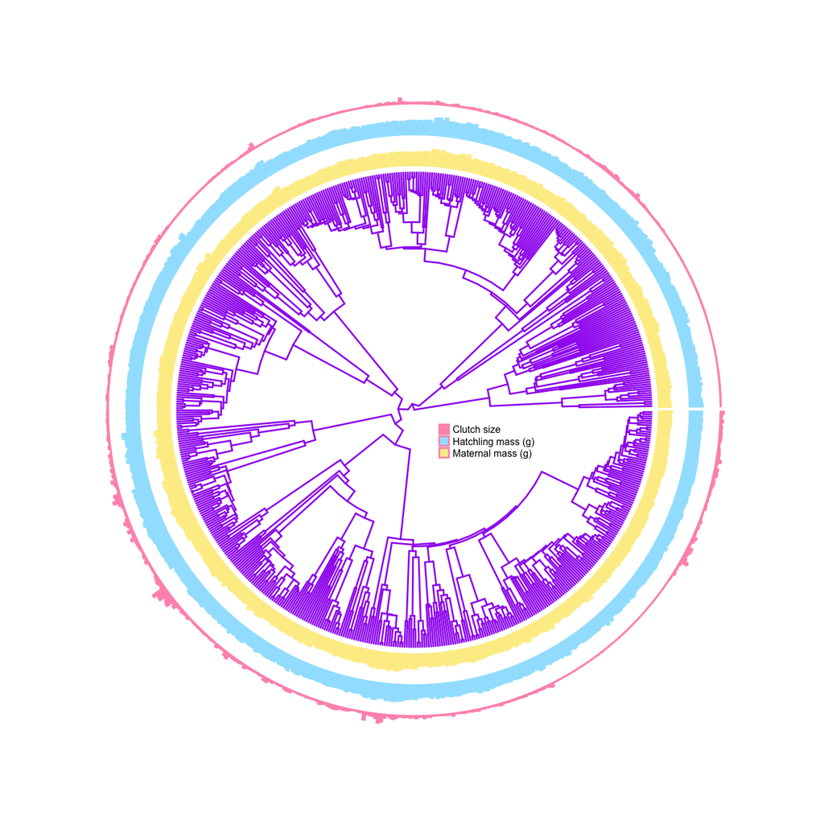

```r
p <- ggtree(ctree_t, layout='circular', colour = "purple")


p + geom_fruit(data=dtree, geom=geom_bar, mapping=aes(x=log(female_mass), y = Binomial, fill = "Maternal mass (g)"), pwidth = 0.1, stat="identity", orientation="y", colour = "#FDED95") + geom_fruit(data=dtree, geom=geom_bar, mapping=aes(x=log(hatchling_mass), y = Binomial, fill = "Hatchling mass (g)"), pwidth = 0.1, stat="identity", orientation="y", colour = "#A0E3FE") + geom_fruit(data=dtree, geom=geom_bar, mapping=aes(x=mclutch, y = Binomial, fill = "Clutch size"), pwidth = 0.07, stat="identity", orientation="y", colour = "#FE97BA") + scale_fill_manual(values=c("#FE97BA", "#A0E3FE", "#FDED95"), guide=guide_legend(keywidth=0.5, keyheight=0.5, order=6, title = "")) + theme(legend.position=c(0.59, 0.461), legend.title=element_text(size=0), legend.text=element_text(size=6), legend.spacing.x = unit(0.06, "cm"))
```

```r
dat_bt_diurnal <- (b1)


dat_bt_diurnal$mclutch <- (dat_bt_diurnal$smallest.mean.clutch.size + dat_bt_diurnal$largest.mean.clutch.size) / 2

dat_bt_diurnal$mean_bt <- (dat_bt_diurnal$minimum.mean.Tb + dat_bt_diurnal$maximum.mean.Tb) / 2

dat_bt_diurnal <- na.omit(dat_bt_diurnal)

tapply(dat_bt_diurnal$female.SVL, dat_bt_diurnal$Family, length)
```

```
           Agamidae          Anguidae       Anniellidae         Bipedidae
                 45                10                 1                 2
   Carphodactylidae    Chamaeleonidae        Cordylidae    Corytophanidae
                  4                 5                 3                 2
      Crotaphytidae       Dactyloidae   Diplodactylidae     Eublepharidae
                  3                55                19                 5
         Gekkonidae    Gerrhosauridae  Gymnophthalmidae    Helodermatidae
                 24                 1                15                 2
      Hoplocercidae         Iguanidae        Lacertidae    Leiocephalidae
                  1                12                61                 4
        Liolaemidae         Opluridae   Phrynosomatidae  Phyllodactylidae
                 24                 1                57                15
      Polychrotidae       Pygopodidae         Scincidae Sphaerodactylidae
                  2                 4               103                 9
            Teiidae    Trogonophiidae      Tropiduridae         Varanidae
                 25                 1                13                17
        Xantusiidae      Xenosauridae
                  5                 6
```

```r
names(dat_bt_diurnal)
```

```
   [1] "Binomial"
   [2] "reproductive.mode"
   [3] "Genus"
   [4] "Family"
   [5] "female.SVL"
   [6] "hatchling.neonate.SVL"
   [7] "intercept"
   [8] "slope"
   [9] "female_mass"
  [10] "hatchling_mass"
  [11] "largest.clutch"
  [12] "smallest.clutch"
  [13] "largest.mean.clutch.size"
  [14] "smallest.mean.clutch.size"
  [15] "Longitude.centroid..from.Roll.et.al..2017."
```

[output cut: 17 more lines]

```r
## Cheking whether the species names macth the tips of the tree

check <- name.check(tree, dat)
rm_phy <- check$tree_not_data
rm_dat <- check$data_not_tree

check_bt_diurnal <- name.check(tree, dat_bt_diurnal)
rm_phy_bt_diurnal <- check_bt_diurnal$tree_not_data
rm_dat_bt_diurnal <- check_bt_diurnal$data_not_tree


## Droping species names from the phylogeny

ctree <- drop.tip(tree, rm_phy)
ctree_bt_diurnal <- drop.tip(tree, rm_phy_bt_diurnal)

cdat <- subset(dat, subset = dat$Binomial %in% ctree$tip, select = names(dat)[1:30])
name.check(ctree, cdat)
```

```
  [1] "OK"
```

```r
names(cdat)
```

```
   [1] "Binomial"
   [2] "Area"
   [3] "FID_2"
   [4] "TID"
   [5] "Group"
   [6] "Value"
   [7] "tempmean"
   [8] "tempstdev"
   [9] "precmean"
  [10] "precstdev"
  [11] "nppmean"
  [12] "nppstdev"
  [13] "annual_temp"
  [14] "reproductive.mode"
  [15] "Genus"
  [16] "Family"
  [17] "female.SVL"
  [18] "hatchling.neonate.SVL"
  [19] "intercept"
  [20] "slope"
  [21] "female_mass"
  [22] "hatchling_mass"
  [23] "largest.clutch"
  [24] "smallest.clutch"
  [25] "largest.mean.clutch.size"
  [26] "smallest.mean.clutch.size"
  [27] "Longitude.centroid..from.Roll.et.al..2017."
  [28] "Latitude.centroid..from.Roll.et.al..2017."
  [29] "Activity.time"
  [30] "mclutch"
```

```r
names(cdat)[c(21, 22, 30, 7, 11, 9)] <- c("FS", "HS", "CS", "ET", "PP", "PR")


cdat$PR <- log1p(cdat$PR)
cdat$PP <- log1p(cdat$PP)
cdat <- na.omit(cdat)

check <- name.check(tree, cdat)
rm_phy <- check$tree_not_data
rm_dat <- check$data_not_tree
ctree <- drop.tip(tree, rm_phy)
name.check(ctree, cdat)
```

```
  [1] "OK"
```

```r
str(cdat)
```

```
  'data.frame': 439 obs. of  30 variables:
   $ Binomial                                  : chr  "Abronia_graminea" "Acanthodactylus_beershebensis" "Acanthodactylus_erythrurus" "Acanthodactylus_longipes" ...
   $ Area                                      : num  2037 5380 1030082 7872081 179337 ...
   $ FID_2                                     : int  21 56 64 74 81 85 86 107 129 241 ...
   $ TID                                       : chr  "R00677" "R05250" "R05258" "R05268" ...
   $ Group                                     : chr  "lizard" "lizard" "lizard" "lizard" ...
   $ Value                                     : int  1 1 1 1 1 1 1 1 1 1 ...
   $ ET                                        : num  11.8 19.1 14.7 24.8 19.5 ...
   $ tempstdev                                 : num  3.19 1 2.64 2.9 1.14 ...
   $ PR                                        : num  7.03 5.44 6.28 3.74 4.69 ...
   $ precstdev                                 : num  289.1 52.6 291.8 40.5 81.6 ...
   $ PP                                        : num  27.2 25 26 23.8 24.4 ...
   $ nppstdev                                  : num  1.13e+11 4.82e+10 1.14e+11 7.98e+09 5.03e+10 ...
   $ annual_temp                               : num  19 19.1 12.9 24.7 18.5 ...
   $ reproductive.mode                         : chr  "Viviparous" "Oviparous" "Oviparous" "Oviparous" ...
```

[output cut: 18 more lines]

```r
cdat_bt_diurnal <- subset(dat_bt_diurnal, subset = dat_bt_diurnal$Binomial %in% ctree_bt_diurnal$tip, select = names(dat_bt_diurnal)[1:32])
name.check(ctree_bt_diurnal, cdat_bt_diurnal)
```

```
  [1] "OK"
```

```r
names(cdat_bt_diurnal)
```

```
   [1] "Binomial"
   [2] "reproductive.mode"
   [3] "Genus"
   [4] "Family"
   [5] "female.SVL"
   [6] "hatchling.neonate.SVL"
   [7] "intercept"
   [8] "slope"
   [9] "female_mass"
  [10] "hatchling_mass"
  [11] "largest.clutch"
  [12] "smallest.clutch"
  [13] "largest.mean.clutch.size"
  [14] "smallest.mean.clutch.size"
  [15] "Longitude.centroid..from.Roll.et.al..2017."
```

[output cut: 17 more lines]

```r
names(cdat_bt_diurnal)[c(9, 10, 31, 32, 29, 27)] <- c("FS", "HS", "CS", "BT", "PP", "PR")

cdat_bt_diurnal$PR <- log1p(cdat_bt_diurnal$PR)
cdat_bt_diurnal$PP <- log(cdat_bt_diurnal$PP)

cdat_bt_diurnal <- na.omit(cdat_bt_diurnal)

check_bt_diurnal <- name.check(tree, cdat_bt_diurnal)
rm_phy_bt_diurnal <- check_bt_diurnal$tree_not_data
rm_dat_bt_diurnal <- check_bt_diurnal$data_not_tree
ctree_bt_diurnal <- drop.tip(tree, rm_phy_bt_diurnal)
name.check(ctree_bt_diurnal, cdat_bt_diurnal)
```

```
  [1] "OK"
```

```r
str(cdat_bt_diurnal)
```

```
  'data.frame': 320 obs. of  32 variables:
   $ Binomial                                  : chr  "Acanthodactylus_beershebensis" "Acanthodactylus_erythrurus" "Acanthodactylus_longipes" "Acanthodactylus_pardalis" ...
   $ reproductive.mode                         : chr  "Oviparous" "Oviparous" "Oviparous" "Oviparous" ...
   $ Genus                                     : chr  "Acanthodactylus" "Acanthodactylus" "Acanthodactylus" "Acanthodactylus" ...
   $ Family                                    : chr  "Lacertidae" "Lacertidae" "Lacertidae" "Lacertidae" ...
   $ female.SVL                                : num  64.9 68.6 46.7 61 69.4 ...
   $ hatchling.neonate.SVL                     : num  25 29 23 30 35.8 24.3 79 29 20.4 22 ...
   $ intercept                                 : num  -4.54 -4.54 -4.54 -4.54 -4.54 ...
   $ slope                                     : num  2.95 2.95 2.95 2.95 2.95 ...
   $ FS                                        : num  187 198 133 175 200 ...
   $ HS                                        : num  69.2 81 63.3 84 101.1 ...
   $ largest.clutch                            : int  8 8 3 7 8 6 4 20 8 8 ...
   $ smallest.clutch                           : int  3 1 2 2 1 1 2 4 1 2 ...
   $ largest.mean.clutch.size                  : num  5 4.4 2.7 4.8 3 3.3 3 14 3.3 4 ...
   $ smallest.mean.clutch.size                 : num  4.8 3 2.7 2.5 2.6 2.5 3 13.4 3.3 3 ...
```

[output cut: 20 more lines]

```r
ml3 <- define_model_set(
    null = c(),
    "(a)" = c(HS ~ ET),
    "(b)" = c(FS ~ ET),
    "(c)" = c(FS ~ ET, HS ~ ET),
    "(d)" = c(FS ~ PP),
    "(e)" = c(FS ~ PR),
    "(f)" = c(HS ~ PR),
    "(g)" = c(FS ~ PR, HS ~ PR),
    "(h)" = c(FS ~ PP + PR + ET, HS ~ ET, HS ~ PR),
    .common = c(CS ~ FS + HS, HS ~ FS, ET ~ PR, PP ~ ET, PP ~ PR))



ml4 <- define_model_set(
    null = c(),
    "(a)" = c(HS ~ BT),
    "(b)" = c(FS ~ BT),
    "(c)" = c(FS ~ BT, HS ~ BT),
    "(d)" = c(FS ~ PP),
    "(e)" = c(FS ~ PR),
    "(f)" = c(HS ~ PR),
    "(g)" = c(FS ~ PR, HS ~ PR),
    "(h)" = c(FS ~ PP + PR + BT, HS ~ BT, HS ~ PR),
    .common = c(CS ~ FS + HS, HS ~ FS, BT ~ PR, BT ~ PP, PP ~ PR))
```

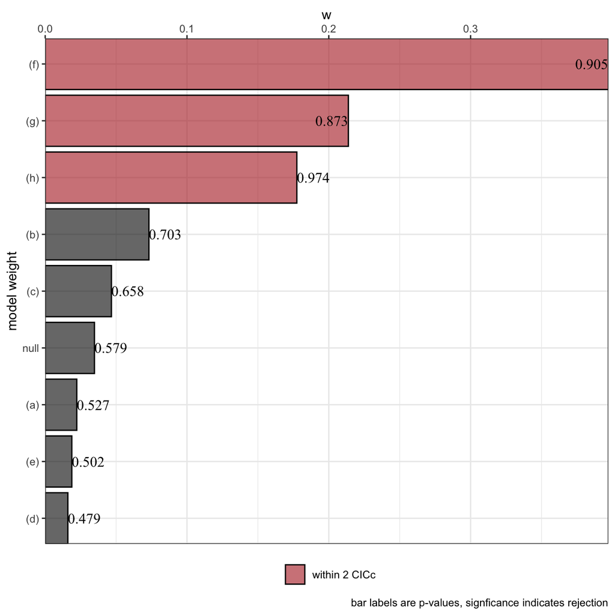

```r
positions <- data.frame(name = c('PP', 'PR', 'ET', 'FS', 'HS', '', 'CS'), x = c(2:3, c(2.5, 1.75, 3.25, 2), 2.5), y = c(3, 3, 2.3, 2, 2, 2, 1))

mo <- phylo_path(ml3, cdat, ctree)
s <- summary(mo)
theme_set(theme_bw())
plot(s)
```

**Table S3.**

```r
kable(summary(mo)[ , 2:9], digits = 3) %>%
  kable_styling(bootstrap_options = "striped", full_width = FALSE, position = "center")
```

k

q

C

p

CICc

delta_CICc

l

w

8

13

9.203

0.905

36.059

0.000

1.000

0.397

7

14

8.307

0.873

37.298

1.238

0.538

0.214

4

17

2.216

0.974

37.670

1.611

0.447

0.177

8

13

12.586

0.703

39.443

3.384

0.184

0.073

7

14

11.350

0.658

40.340

4.281

0.118

0.047

null

9

12

16.200

0.579

40.933

4.873

0.087

0.035

8

13

14.963

0.527

41.820

5.761

0.056

0.022

8

13

15.305

0.502

42.161

6.102

0.047

0.019

8

13

15.629

0.479

42.486

6.426

0.040

0.016

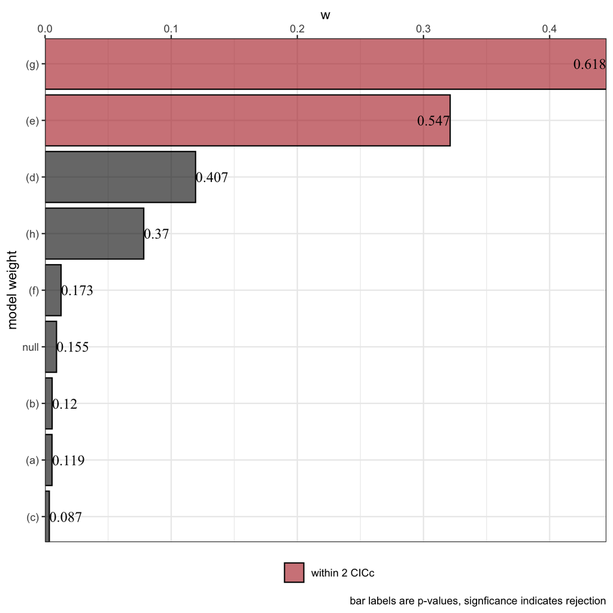

```r
positions.bt <- data.frame(name = c('PP', 'PR', 'BT', 'FS', 'HS', '', 'CS'), x = c(2:3, c(2.6, 1.75, 3.25, 2), 2.5), y = c(3, 3, 2.2, 2, 2, 2, 1))

mo_bt_diurnal <- phylo_path(ml4, cdat_bt_diurnal, ctree_bt_diurnal)
s.bt <- summary(mo_bt_diurnal)
theme_set(theme_bw())
plot(s.bt)
```

**Table S4.**

```r
kable(summary(mo_bt_diurnal)[ , 2:9], digits = 3) %>%
  kable_styling(bootstrap_options = "striped", full_width = FALSE, position = "center")
```

k

q

C

p

CICc

delta_CICc

l

w

7

14

11.851

0.618

41.229

0.000

1.000

0.445

8

13

14.691

0.547

41.881

0.652

0.722

0.321

8

13

16.671

0.407

43.861

2.632

0.268

0.119

4

17

8.679

0.370

44.705

3.477

0.176

0.078

8

13

21.152

0.173

48.342

7.113

0.029

0.013

null

9

12

23.992

0.155

49.008

7.780

0.020

0.009

8

13

22.786

0.120

49.976

8.748

0.013

0.006

8

13

22.816

0.119

50.005

8.777

0.012

0.006

7

14

21.610

0.087

50.987

9.759

0.008

0.003

```r
mo$d_sep
```

```
  $null
  # A tibble: 9 × 4
    d_sep                            p phylo_par model
    <chr>                        <dbl>     <dbl> <list>
  1 FS ~ PR                     0.639      0.986 <phylolm>
  2 HS ~ FS + PR                0.0302     0.853 <phylolm>
  3 CS ~ FS + HS + PR           0.863      0.961 <phylolm>
  4 FS ~ PR + ET                0.122      0.986 <phylolm>
  5 HS ~ PR + FS + ET           0.393      0.854 <phylolm>
  6 CS ~ PR + FS + HS + ET      0.611      0.960 <phylolm>
  7 FS ~ PR + ET + PP           0.992      0.986 <phylolm>
  8 HS ~ PR + ET + FS + PP      0.704      0.854 <phylolm>
  9 CS ~ PR + ET + FS + HS + PP 0.890      0.960 <phylolm>

  $`(a)`
  # A tibble: 8 × 4
    d_sep                            p phylo_par model
    <chr>                        <dbl>     <dbl> <list>
  1 FS ~ PR                     0.639      0.986 <phylolm>
  2 HS ~ ET + FS + PR           0.0220     0.854 <phylolm>
  3 CS ~ FS + HS + PR           0.863      0.961 <phylolm>
  4 FS ~ PR + ET                0.122      0.986 <phylolm>
  5 CS ~ PR + FS + HS + ET      0.611      0.960 <phylolm>
  6 FS ~ PR + ET + PP           0.992      0.986 <phylolm>
  7 HS ~ PR + ET + FS + PP      0.704      0.854 <phylolm>
  8 CS ~ PR + ET + FS + HS + PP 0.890      0.960 <phylolm>

  $`(b)`
  # A tibble: 8 × 4
    d_sep                            p phylo_par model
    <chr>                        <dbl>     <dbl> <list>
  1 FS ~ ET + PR                0.475      0.986 <phylolm>
  2 HS ~ FS + PR                0.0302     0.853 <phylolm>
  3 CS ~ FS + HS + PR           0.863      0.961 <phylolm>
  4 HS ~ PR + FS + ET           0.393      0.854 <phylolm>
  5 CS ~ PR + FS + HS + ET      0.611      0.960 <phylolm>
  6 FS ~ PR + ET + PP           0.992      0.986 <phylolm>
  7 HS ~ PR + ET + FS + PP      0.704      0.854 <phylolm>
  8 CS ~ PR + ET + FS + HS + PP 0.890      0.960 <phylolm>

```

[output cut: 56 more lines]

```
  2 FS ~ PR + ET                0.122     0.986 <phylolm>
  3 HS ~ PR + FS + ET           0.393     0.854 <phylolm>
  4 CS ~ PR + FS + HS + ET      0.611     0.960 <phylolm>
  5 FS ~ PR + ET + PP           0.992     0.986 <phylolm>
  6 HS ~ PR + ET + FS + PP      0.704     0.854 <phylolm>
  7 CS ~ PR + ET + FS + HS + PP 0.890     0.960 <phylolm>

  $`(h)`
  # A tibble: 4 × 4
    d_sep                           p phylo_par model
    <chr>                       <dbl>     <dbl> <list>
  1 CS ~ FS + HS + PR           0.863     0.961 <phylolm>
  2 CS ~ PR + FS + HS + ET      0.611     0.960 <phylolm>
  3 HS ~ PR + ET + FS + PP      0.704     0.854 <phylolm>
  4 CS ~ PR + ET + FS + HS + PP 0.890     0.960 <phylolm>
```

```r
mo_bt_diurnal$d_sep
```

```
  $null
  # A tibble: 9 × 4
    d_sep                             p phylo_par model
    <chr>                         <dbl>     <dbl> <list>
  1 FS ~ PR                     0.00956     0.994 <phylolm>
  2 HS ~ FS + PR                0.242       0.867 <phylolm>
  3 CS ~ FS + HS + PR           0.510       0.812 <phylolm>
  4 FS ~ PR + PP                0.698       0.995 <phylolm>
  5 HS ~ PR + FS + PP           0.462       0.866 <phylolm>
  6 CS ~ PR + FS + HS + PP      0.725       0.814 <phylolm>
  7 FS ~ PR + PP + BT           0.605       0.995 <phylolm>
  8 HS ~ PR + PP + FS + BT      0.466       0.865 <phylolm>
  9 CS ~ PR + PP + FS + HS + BT 0.0795      0.828 <phylolm>

  $`(a)`
  # A tibble: 8 × 4
    d_sep                             p phylo_par model
    <chr>                         <dbl>     <dbl> <list>
  1 FS ~ PR                     0.00956     0.994 <phylolm>
  2 HS ~ BT + FS + PR           0.211       0.867 <phylolm>
  3 CS ~ FS + HS + PR           0.510       0.812 <phylolm>
  4 FS ~ PR + PP                0.698       0.995 <phylolm>
  5 HS ~ PR + BT + FS + PP      0.444       0.865 <phylolm>
  6 CS ~ PR + FS + HS + PP      0.725       0.814 <phylolm>
  7 FS ~ PR + PP + BT           0.605       0.995 <phylolm>
  8 CS ~ PR + PP + FS + HS + BT 0.0795      0.828 <phylolm>

  $`(b)`
  # A tibble: 8 × 4
    d_sep                            p phylo_par model
    <chr>                        <dbl>     <dbl> <list>
  1 FS ~ BT + PR                0.0103     0.995 <phylolm>
  2 HS ~ FS + PR                0.242      0.867 <phylolm>
  3 CS ~ FS + HS + PR           0.510      0.812 <phylolm>
  4 FS ~ PR + BT + PP           0.716      0.995 <phylolm>
  5 HS ~ PR + FS + PP           0.462      0.866 <phylolm>
  6 CS ~ PR + FS + HS + PP      0.725      0.814 <phylolm>
  7 HS ~ PR + PP + FS + BT      0.466      0.865 <phylolm>
  8 CS ~ PR + PP + FS + HS + BT 0.0795     0.828 <phylolm>

```

[output cut: 56 more lines]

```
  2 FS ~ PR + PP                0.698      0.995 <phylolm>
  3 HS ~ PR + FS + PP           0.462      0.866 <phylolm>
  4 CS ~ PR + FS + HS + PP      0.725      0.814 <phylolm>
  5 FS ~ PR + PP + BT           0.605      0.995 <phylolm>
  6 HS ~ PR + PP + FS + BT      0.466      0.865 <phylolm>
  7 CS ~ PR + PP + FS + HS + BT 0.0795     0.828 <phylolm>

  $`(h)`
  # A tibble: 4 × 4
    d_sep                            p phylo_par model
    <chr>                        <dbl>     <dbl> <list>
  1 CS ~ FS + HS + PR           0.510      0.812 <phylolm>
  2 HS ~ PR + BT + FS + PP      0.444      0.865 <phylolm>
  3 CS ~ PR + FS + HS + PP      0.725      0.814 <phylolm>
  4 CS ~ PR + PP + FS + HS + BT 0.0795     0.828 <phylolm>
```

**Model averaging**

```r
avg <- average(mo, avg_method = "full", cut_off = 2)
avg
```

```
  $coef
                FS PR        ET           PP           HS         CS
  FS  0.0000000000  0 0.0000000  0.000000000  0.759612286  0.6927891
  PR  0.0120520392  0 0.1801509  0.863724467 -0.044536800  0.0000000
  ET -0.0146563732  0 0.0000000 -0.001114894  0.004024552  0.0000000
  PP  0.0001652414  0 0.0000000  0.000000000  0.000000000  0.0000000
  HS  0.0000000000  0 0.0000000  0.000000000  0.000000000 -0.5078921
  CS  0.0000000000  0 0.0000000  0.000000000  0.000000000  0.0000000
  attr(,"class")
  [1] "matrix" "DAG"

  $se
             FS PR         ET         PP         HS         CS
  FS 0.00000000  0 0.00000000 0.00000000 0.02239613 0.08236232
  PR 0.04439068  0 0.04688044 0.02648326 0.02027142 0.00000000
  ET 0.03374599  0 0.00000000 0.02700766 0.01241059 0.00000000
  PP 0.03488868  0 0.00000000 0.00000000 0.00000000 0.00000000
  HS 0.00000000  0 0.00000000 0.00000000 0.00000000 0.09435962
  CS 0.00000000  0 0.00000000 0.00000000 0.00000000 0.00000000

  $lower
              FS PR         ET          PP          HS         CS
  FS  0.00000000  0 0.00000000  0.00000000  0.71571667  0.5313619
  PR -0.07495209  0 0.08826695  0.81181822 -0.08426805  0.0000000
  ET -0.08079730  0 0.00000000 -0.05404894 -0.02029976  0.0000000
  PP -0.06821531  0 0.00000000  0.00000000  0.00000000  0.0000000
  HS  0.00000000  0 0.00000000  0.00000000  0.00000000 -0.6928336
  CS  0.00000000  0 0.00000000  0.00000000  0.00000000  0.0000000

  $upper
             FS PR        ET         PP           HS         CS
  FS 0.00000000  0 0.0000000 0.00000000  0.803507902  0.8542163
  PR 0.09905617  0 0.2720349 0.91563071 -0.004805548  0.0000000
  ET 0.05148455  0 0.0000000 0.05181915  0.028348862  0.0000000
  PP 0.06854579  0 0.0000000 0.00000000  0.000000000  0.0000000
  HS 0.00000000  0 0.0000000 0.00000000  0.000000000 -0.3229507
  CS 0.00000000  0 0.0000000 0.00000000  0.000000000  0.0000000

  attr(,"class")
  [1] "fitted_DAG"
```

```r
avg_bt_diurnal <- average(mo_bt_diurnal, avg_method = "full", cut_off = 2)
avg_bt_diurnal
```

```
  $coef
     PR        PP          BT        FS          HS         CS
  PR  0 0.8435276 -0.02689343 0.1256964 -0.01712392  0.0000000
  PP  0 0.0000000 -0.07015859 0.0000000  0.00000000  0.0000000
  BT  0 0.0000000  0.00000000 0.0000000  0.00000000  0.0000000
  FS  0 0.0000000  0.00000000 0.0000000  0.78878338  0.9065708
  HS  0 0.0000000  0.00000000 0.0000000  0.00000000 -0.7142563
  CS  0 0.0000000  0.00000000 0.0000000  0.00000000  0.0000000
  attr(,"class")
  [1] "matrix" "DAG"

  $se
     PR         PP         BT         FS         HS       CS
  PR  0 0.02900682 0.08927395 0.04821103 0.02405605 0.000000
  PP  0 0.00000000 0.08849381 0.00000000 0.00000000 0.000000
  BT  0 0.00000000 0.00000000 0.00000000 0.00000000 0.000000
  FS  0 0.00000000 0.00000000 0.00000000 0.02799693 0.102159
  HS  0 0.00000000 0.00000000 0.00000000 0.00000000 0.109283
  CS  0 0.00000000 0.00000000 0.00000000 0.00000000 0.000000

  $lower
     PR        PP         BT         FS          HS         CS
  PR  0 0.7866753 -0.2018672 0.03120456 -0.06427291  0.0000000
  PP  0 0.0000000 -0.2436033 0.00000000  0.00000000  0.0000000
  BT  0 0.0000000  0.0000000 0.00000000  0.00000000  0.0000000
  FS  0 0.0000000  0.0000000 0.00000000  0.73391041  0.7063429
  HS  0 0.0000000  0.0000000 0.00000000  0.00000000 -0.9284471
  CS  0 0.0000000  0.0000000 0.00000000  0.00000000  0.0000000

  $upper
     PR        PP        BT        FS         HS         CS
  PR  0 0.9003799 0.1480803 0.2201883 0.03002507  0.0000000
  PP  0 0.0000000 0.1032861 0.0000000 0.00000000  0.0000000
  BT  0 0.0000000 0.0000000 0.0000000 0.00000000  0.0000000
  FS  0 0.0000000 0.0000000 0.0000000 0.84365635  1.1067988
  HS  0 0.0000000 0.0000000 0.0000000 0.00000000 -0.5000656
  CS  0 0.0000000 0.0000000 0.0000000 0.00000000  0.0000000

  attr(,"class")
  [1] "fitted_DAG"
```

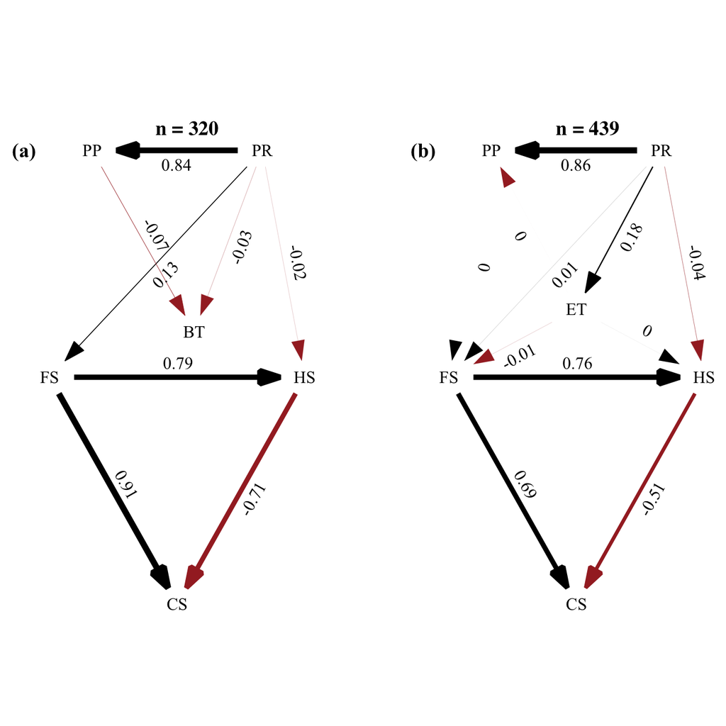

```r
set_graph_style(family = "Times New Roman", text_size = 12)

d2 <- plot(avg_bt_diurnal, manual_layout = positions.bt, text_size = 4.2, edge_width = 0.05, curvature = -0, colors = c("brown", "black")) + ggplot2::scale_x_continuous(expand = c(0.2, 0)) + ggplot2::scale_y_continuous(expand = c(0.1, 0)) + theme(plot.margin=unit(c(0, 0, 0, 0), "cm")) + theme(legend.text = element_text(size = 13, family = "serif")) + theme(plot.title = element_text(size = 14, family = "serif", face = "bold")) + annotate(geom = "text", x = 2.74, y = 2.07, angle = 0, label = "", size = 3.8) + annotate(geom = "text", angle = 300, x = 2.33, y = 1.38, label = "", size = 3.8) + annotate(geom = "text", x = 3.06, y = 1.63, angle = 59, label = "", size = 3.8) + ggtitle("n = 320") + theme(plot.title = element_text(hjust = 0.566, vjust = -10), legend.position = "none")

d3 <- plot(avg, manual_layout = positions, text_size = 4.2, edge_width = 0.05, curvature = -0, colors = c("brown", "black")) + ggplot2::scale_x_continuous(expand = c(0.2, 0)) + ggplot2::scale_y_continuous(expand = c(0.1, 0)) + theme(plot.margin=unit(c(0, 0, 0, 0), "cm")) + theme(legend.text = element_text(size = 13, family = "serif")) + theme(plot.title = element_text(size = 14, family = "serif", face = "bold")) + annotate(geom = "text", x = 2.74, y = 2.07, angle = 0, label = "", size = 3.8) + annotate(geom = "text", angle = 300, x = 2.33, y = 1.38, label = "", size = 3.8) + annotate(geom = "text", x = 3.06, y = 1.63, angle = 59, label = "", size = 3.8) + theme(plot.title = element_text(hjust = 0.57, vjust = -10), legend.position = "none") + ggtitle("n = 439")


grob <- grobTree(textGrob("(a)", x = 0.09,  y = 0.97, hjust = 0, gp = gpar(fontsize = 12, fontface = "bold", fontfamily = "Times New Roman")))

grob2 <- grobTree(textGrob("(b)", x = 0.09,  y = 0.97, hjust = 0, gp = gpar(fontsize = 12, fontface = "bold", fontfamily = "Times New Roman")))

c1 <- d2 + annotate(geom = "text", x = 2.73, y = 2.934, angle = 0, label = "", size = 3.8) + annotate(geom = "text", x = 3.26, y = 2.324, angle = 280, label = "", size = 3.8) + annotate(geom = "text", x = 2.26, y = 2.57, angle = 298, label = "", size = 3.8) + annotate(geom = "text", x = 2.95, y = 2.75, angle = 72, label = "", size = 3.8) + annotate(geom = "text", x = 2.58, y = 2.59, angle = 48, label = "", size = 3.8) + annotate(geom = "text", x = 1.6, y = 3, label = "(a)", size = 5, fontface = 2)

c2 <- d3 + annotate(geom = "text", x = 2.73, y = 2.934, angle = 0, label = "", size = 3.8) + annotate(geom = "text", x = 3.26, y = 2.324, angle = 278, label = "", size = 3.8) + annotate(geom = "text", x = 2.28, y = 2.69, angle = 298, label = "", size = 3.8) + annotate(geom = "text", x = 2.92, y = 2.78, angle = 66, label = "", size = 3.8) + annotate(geom = "text", x = 2.58, y = 2.59, angle = 48, label = "", size = 3.8) + annotate(geom = "text", x = 1.6, y = 3, label = "(b)", size = 5, fontface = 2)

quartz()
grid.arrange(grobs = list(c1, c2), ncol = 2, vp = viewport(width = 1.1, height = 0.8), layout_matrix = rbind(c(1, 2), c(1, 2)))
```